# Some examples of use-cases using the market models of the package

## Package *diseq* is deprecated. Please use package *markets* instead.

This short tutorial covers the very basic use cases to get you started with *diseq*. More usage details can be found in the documentation of the package.

## Setup the environment

Load the required libraries.

```r
library(diseq)
library(magrittr)
library(Formula)
```

Prepare the data. Normally this step is long and depends on the nature of the data and the considered market. For this example, we will use simulated data. Although we could simulate data independently from the package, we will use the top-level simulation functionality of *diseq* to simplify the process. See the documentation of `simulate_data` for more information on the simulation functionality. Here, we simulate data using a data generating process for a market in disequilibrium with stochastic price dynamics.

```r
nobs <- 1000
tobs <- 10

alpha_d <- -0.3
beta_d0 <- 6.8
beta_d <- c(0.3, -0.02)
eta_d <- c(0.6, -0.1)

alpha_s <- 0.6
beta_s0 <- 4.1
beta_s <- c(0.9)
eta_s <- c(-0.5, 0.2)

gamma <- 1.2
beta_p0 <- 0.9
beta_p <- c(-0.1)

sigma_d <- 1
sigma_s <- 1
sigma_p <- 1
rho_ds <- 0.0
rho_dp <- 0.0
rho_sp <- 0.0

seed <- 4430

stochastic_adjustment_data <- simulate_data(
  "diseq_stochastic_adjustment", nobs, tobs,
  alpha_d, beta_d0, beta_d, eta_d,
  alpha_s, beta_s0, beta_s, eta_s,
  gamma, beta_p0, beta_p,
  sigma_d = sigma_d, sigma_s = sigma_s, sigma_p = sigma_p,
  rho_ds = rho_ds, rho_dp = rho_dp, rho_sp = rho_sp,
  seed = seed
)
```

## Estimate the models

Prepare the basic parameters for model initialization. The `simulate_data` call uses `Q` for the simulated traded quantity, `P` for the simulated prices, `id` for subject identification, and `date` for time identification. It automatically creates the demand-specific variables `Xd1` and `Xd2`, the supply-specific variable `Xs1`, the common (i.e., both demand and supply) variables `X1` and `X2`, and the price dynamics’ variable `Xp1`.

```r
market_spec <- Q | P | id | date ~ P + Xd1 + Xd2 + X1 + X2 | P + Xs1 + X1 + X2
```

The market specification has to be modified in two cases. For the `diseq_directional`, the price variable is removed from the supply equation because the separation rule of the model can only be used for markets with exclusively either inelastic demand or supply. For the `diseq_stochastic_adjustment`, the right-hand side of the price dynamics equation is appended in the market specification.

By default, the models are estimated by allowing the demand, supply, and price equations to have correlated error shocks. The default verbosity behavior is to display errors and warnings that might occur when estimating the models.

By default, all models are estimated using full information maximum likelihood based on the `"BFGS"` optimization algorithm. The first `equilibrium_model` call modifies the estimation behavior and estimates the model using two stage least squares. The `diseq_basic` call modifies the default optimization behavior and estimates the model using the `"Nelder-Mead"` optimization methods.

Standard errors are by default assumed to be homoscedastic. The second `equilibrium_model` and `diseq_deterministic_adjustment` calls modify this behavior by calculating clustered standard errors based on the subject identifier, while the `diseq_basic` and `diseq_directional` calls modify it by calculating heteroscedastic standard errors via the sandwich estimator.

```r
eq_reg <- equilibrium_model(
  market_spec, stochastic_adjustment_data,
  estimation_options = list(method = "2SLS")
)
eq_fit <- equilibrium_model(
  market_spec, stochastic_adjustment_data,
  estimation_options = list(standard_errors = c("id"))
)
bs_fit <- diseq_basic(
  market_spec, stochastic_adjustment_data,
  estimation_options = list(
    method = "Nelder-Mead", control = list(maxit = 1e+5),
    standard_errors = "heteroscedastic"
  )
)
dr_fit <- diseq_directional(
  formula(update(Formula(market_spec), . ~ . | . - P)),
  stochastic_adjustment_data,
  estimation_options = list(standard_errors = "heteroscedastic")
)
da_fit <- diseq_deterministic_adjustment(
  market_spec, stochastic_adjustment_data,
  estimation_options = list(standard_errors = c("id"))
)
sa_fit <- diseq_stochastic_adjustment(
  formula(update(Formula(market_spec), . ~ . | . | Xp1)),
  stochastic_adjustment_data,
  estimation_options = list(control = list(maxit = 1e+5))
)
```

## Post estimation analysis

### Summaries

All the model estimates support the `summary` function. The `eq_2sls` also provides the first-stage estimation, but it is not included in the summary and has to be explicitly asked.

```r
summary(eq_reg@fit[[1]]$first_stage_model)
```

```
#>
#> Call:
#> lm(formula = first_stage_formula, data = object@model_tibble)
#>
#> Residuals:
#>     Min      1Q  Median      3Q     Max
#> -4.8178 -0.9065  0.0739  0.9472  5.0795
#>
#> Coefficients:
#>             Estimate Std. Error t value Pr(>|t|)
#> (Intercept)  3.64003    0.01388 262.278   <2e-16 ***
#> Xd1          0.12367    0.01385   8.932   <2e-16 ***
#> Xd2          0.02181    0.01379   1.582    0.114
#> X1           0.53012    0.01398  37.920   <2e-16 ***
#> X2          -0.14884    0.01392 -10.689   <2e-16 ***
#> Xs1         -0.41736    0.01401 -29.793   <2e-16 ***
#> ---
#> Signif. codes:  0 '***' 0.001 '**' 0.01 '*' 0.05 '.' 0.1 ' ' 1
#>
#> Residual standard error: 1.388 on 9994 degrees of freedom
#> Multiple R-squared:  0.2035, Adjusted R-squared:  0.2031
#> F-statistic: 510.7 on 5 and 9994 DF,  p-value: < 2.2e-16
```

```r
summary(eq_reg)
```

```
#> Equilibrium Model for Markets in Equilibrium
#>   Demand RHS        : D_P + D_Xd1 + D_Xd2 + D_X1 + D_X2
#>   Supply RHS        : S_P + S_Xs1 + S_X1 + S_X2
#>   Market Clearing   : Q = D_Q = S_Q
#>   Shocks            : Correlated
#>   Nobs              : 10000
#>   Sample Separation : Not Separated
#>   Quantity Var      : Q
#>   Price Var         : P
#>   Key Var(s)        : id, date
#>   Time Var          : date
#>
#> systemfit results
#> method: 2SLS
#>
#>            N    DF     SSR detRCov   OLS-R2 McElroy-R2
#> system 20000 19989 63597.8 7.01273 -2.34127  -0.569281
#>
#>            N   DF     SSR     MSE    RMSE       R2   Adj R2
#> demand 10000 9994 22716.4 2.27300 1.50765 -1.38693 -1.38812
#> supply 10000 9995 40881.4 4.09018 2.02242 -3.29562 -3.29734
#>
#> The covariance matrix of the residuals
#>          demand   supply
#> demand  2.27300 -1.51138
#> supply -1.51138  4.09018
#>
#> The correlations of the residuals
#>          demand   supply
#> demand  1.00000 -0.49568
#> supply -0.49568  1.00000
#>
#>
#> 2SLS estimates for 'demand' (equation 1)
#> Model Formula: Q ~ P + Xd1 + Xd2 + X1 + X2
#> <environment: 0x557cd702c540>
#> Instruments: ~Xd1 + Xd2 + X1 + X2 + Xs1
#> <environment: 0x557cd702c540>
#>
#>               Estimate Std. Error   t value   Pr(>|t|)
```

[output cut: 19 more lines]

```
#> <environment: 0x557cd702c540>
#>
#>               Estimate Std. Error  t value   Pr(>|t|)
#> (Intercept)  0.1023863  0.5854996  0.17487    0.86119
#> P            1.4348674  0.1608244  8.92195 < 2.22e-16 ***
#> Xs1          0.9212974  0.0700887 13.14474 < 2.22e-16 ***
#> X1          -0.5480705  0.0874744 -6.26550 3.8696e-10 ***
#> X2           0.2187621  0.0316162  6.91930 4.8170e-12 ***
#> ---
#> Signif. codes:  0 '***' 0.001 '**' 0.01 '*' 0.05 '.' 0.1 ' ' 1
#>
#> Residual standard error: 2.02242 on 9995 degrees of freedom
#> Number of observations: 10000 Degrees of Freedom: 9995
#> SSR: 40881.386345 MSE: 4.090184 Root MSE: 2.02242
#> Multiple R-Squared: -3.295622 Adjusted R-Squared: -3.297341
```

```r
summary(eq_fit)
```

```
#> Equilibrium Model for Markets in Equilibrium
#>   Demand RHS        : D_P + D_Xd1 + D_Xd2 + D_X1 + D_X2
#>   Supply RHS        : S_P + S_Xs1 + S_X1 + S_X2
#>   Market Clearing   : Q = D_Q = S_Q
#>   Shocks            : Correlated
#>   Nobs              : 10000
#>   Sample Separation : Not Separated
#>   Quantity Var      : Q
#>   Price Var         : P
#>   Key Var(s)        : id, date
#>   Time Var          : date
#>
#> Maximum likelihood estimation
#>   Method              : BFGS
#>   Convergence Status  : success
#>   Starting Values     :
#>        D_P    D_CONST      D_Xd1      D_Xd2       D_X1       D_X2        S_P
#>   -0.77287    8.13837    0.27880    0.01473    0.62228   -0.10960    1.43487
#>    S_CONST      S_Xs1       S_X1       S_X2 D_VARIANCE S_VARIANCE        RHO
#>    0.10239    0.92130   -0.54807    0.21876    2.27300    4.09018   -0.49568
#>
#> Coefficients
#>             Estimate Std. Error  z value      Pr(z)
#> D_P        -0.773054    0.03680 -21.0049  5.921e-98
#> D_CONST     8.138923    0.13410  60.6922  0.000e+00
#> D_Xd1       0.280904    0.01547  18.1592  1.085e-73
#> D_Xd2       0.002508    0.01301   0.1928  8.471e-01
#> D_X1        0.622361    0.02465  25.2478 1.197e-140
#> D_X2       -0.109567    0.01601  -6.8434  7.735e-12
#> S_P         1.435378    0.14831   9.6785  3.721e-22
#> S_CONST     0.100696    0.54024   0.1864  8.521e-01
#> S_Xs1       0.921469    0.06485  14.2095  7.994e-46
#> S_X1       -0.548316    0.08118  -6.7541  1.437e-11
#> S_X2        0.218814    0.03010   7.2702  3.590e-13
#> D_VARIANCE  2.272293    0.13186  17.2327  1.509e-66
#> S_VARIANCE  4.089835    0.75335   5.4289  5.670e-08
#> RHO        -0.495957    0.04181 -11.8623  1.858e-32
#>
#> -2 log L: 60383.5
```

```r
summary(bs_fit)
```

```
#> Basic Model for Markets in Disequilibrium
#>   Demand RHS        : D_P + D_Xd1 + D_Xd2 + D_X1 + D_X2
#>   Supply RHS        : S_P + S_Xs1 + S_X1 + S_X2
#>   Short Side Rule   : Q = min(D_Q, S_Q)
#>   Shocks            : Correlated
#>   Nobs              : 10000
#>   Sample Separation : Not Separated
#>   Quantity Var      : Q
#>   Price Var         : P
#>   Key Var(s)        : id, date
#>   Time Var          : date
#>
#> Maximum likelihood estimation
#>   Method              : Nelder-Mead
#>   Max Iterations      : 100000
#>   Convergence Status  : success
#>   Starting Values     :
#>        D_P    D_CONST      D_Xd1      D_Xd2       D_X1       D_X2        S_P
#>   0.044738   5.161505   0.178662  -0.001769   0.185406   0.015149   0.128093
#>    S_CONST      S_Xs1       S_X1       S_X2 D_VARIANCE S_VARIANCE        RHO
#>   4.857007   0.376491   0.143151   0.021754   0.871035   0.775016   0.000000
#>
#> Coefficients
#>            Estimate Std. Error   z value      Pr(z)
#> D_P        -0.04710    0.01220  -3.86141  1.127e-04
#> D_CONST     5.96478    0.05151 115.79794  0.000e+00
#> D_Xd1       0.23523    0.01395  16.86213  8.546e-64
#> D_Xd2      -0.02331    0.01359  -1.71530  8.629e-02
#> D_X1        0.49477    0.02027  24.41089 1.311e-131
#> D_X2       -0.00153    0.01880  -0.08137  9.351e-01
#> S_P         0.36492    0.02044  17.85637  2.579e-71
#> S_CONST     4.81479    0.05047  95.39849  0.000e+00
#> S_Xs1       0.77298    0.02449  31.55999 1.308e-218
#> S_X1       -0.28517    0.02741 -10.40492  2.355e-25
#> S_X2        0.05738    0.02387   2.40392  1.622e-02
#> D_VARIANCE  0.85101    0.02030  41.92772  0.000e+00
#> S_VARIANCE  0.81718    0.02306  35.43429 5.065e-275
#> RHO         0.07948    0.04165   1.90818  5.637e-02
#>
#> -2 log L: 25178.6
```

```r
summary(da_fit)
```

```
#> Deterministic Adjustment Model for Markets in Disequilibrium
#>   Demand RHS        : D_P + D_Xd1 + D_Xd2 + D_X1 + D_X2
#>   Supply RHS        : S_P + S_Xs1 + S_X1 + S_X2
#>   Short Side Rule   : Q = min(D_Q, S_Q)
#>   Separation Rule   : P_DIFF analogous to (D_Q - S_Q)
#>   Shocks            : Correlated
#>   Nobs              : 9000
#>   Sample Separation : Demand Obs = 3731, Supply Obs = 5269
#>   Quantity Var      : Q
#>   Price Var         : P
#>   Key Var(s)        : id, date
#>   Time Var          : date
#>
#> Maximum likelihood estimation
#>   Method              : BFGS
#>   Convergence Status  : success
#>   Starting Values     :
#>        D_P    D_CONST      D_Xd1      D_Xd2       D_X1       D_X2        S_P
#>   0.025528   5.258982   0.190255   0.002401   0.224474   0.012186   0.118691
#>    S_CONST      S_Xs1       S_X1       S_X2     P_DIFF D_VARIANCE S_VARIANCE
#>   4.900087   0.351146   0.175962   0.018346   0.967398   0.842610   0.769177
#>        RHO
#>   0.000000
#>
#> Coefficients
#>             Estimate Std. Error  z value      Pr(z)
#> D_P        -0.282794   0.013288 -21.2811 1.698e-100
#> D_CONST     6.858767   0.057988 118.2796  0.000e+00
#> D_Xd1       0.185900   0.013316  13.9607  2.708e-44
#> D_Xd2       0.008247   0.010004   0.8244  4.097e-01
#> D_X1        0.567684   0.015732  36.0853 3.856e-285
#> D_X2       -0.086836   0.012297  -7.0617  1.645e-12
#> S_P         0.208697   0.013136  15.8877  7.705e-57
#> S_CONST     4.799437   0.047215 101.6500  0.000e+00
#> S_Xs1       0.481558   0.013321  36.1513 3.555e-286
#> S_X1       -0.005406   0.013757  -0.3929  6.944e-01
#> S_X2        0.065150   0.009496   6.8605  6.864e-12
#> P_DIFF      0.614386   0.017232  35.6539 2.052e-278
#> D_VARIANCE  1.277953   0.032092  39.8214  0.000e+00
#> S_VARIANCE  0.760055   0.013868  54.8083  0.000e+00
#> RHO         0.539373   0.022818  23.6381 1.565e-123
#>
#> -2 log L: 45914.2
```

```r
summary(sa_fit)
```

```
#> Stochastic Adjustment Model for Markets in Disequilibrium
#>   Demand RHS        : D_P + D_Xd1 + D_Xd2 + D_X1 + D_X2
#>   Supply RHS        : S_P + S_Xs1 + S_X1 + S_X2
#>   Price Dynamics RHS: (D_Q - S_Q) + Xp1
#>   Short Side Rule   : Q = min(D_Q, S_Q)
#>   Shocks            : Correlated
#>   Nobs              : 9000
#>   Sample Separation : Not Separated
#>   Quantity Var      : Q
#>   Price Var         : P
#>   Key Var(s)        : id, date
#>   Time Var          : date
#>
#> Maximum likelihood estimation
#>   Method              : BFGS
#>   Max Iterations      : 100000
#>   Convergence Status  : success
#>   Starting Values     :
#>        D_P    D_CONST      D_Xd1      D_Xd2       D_X1       D_X2        S_P
#>   0.025528   5.258982   0.190255   0.002401   0.224474   0.012186   0.118691
#>    S_CONST      S_Xs1       S_X1       S_X2     P_DIFF    P_CONST      P_Xp1
#>   4.900087   0.351146   0.175962   0.018346   0.968928   0.275093  -0.062290
#> D_VARIANCE S_VARIANCE P_VARIANCE     RHO_DS     RHO_DP     RHO_SP
#>   0.842610   0.769177   1.600380   0.000000   0.000000   0.000000
#>
#> Coefficients
#>              Estimate Std. Error   z value      Pr(z)
#> D_P        -0.3195795    0.01407 -22.70704 3.817e-114
#> D_CONST     6.9163194    0.06554 105.52917  0.000e+00
#> D_Xd1       0.2874772    0.01236  23.24957 1.437e-119
#> D_Xd2       0.0070640    0.01187   0.59507  5.518e-01
#> D_X1        0.6064175    0.01726  35.14005 1.650e-270
#> D_X2       -0.0980891    0.01253  -7.82584  5.043e-15
#> S_P         0.6163763    0.03164  19.48246  1.547e-84
#> S_CONST     3.9961080    0.07155  55.85034  0.000e+00
#> S_Xs1       0.8989133    0.03142  28.60665 5.553e-180
#> S_X1       -0.4975437    0.03701 -13.44210  3.426e-41
#> S_X2        0.2036846    0.01678  12.13507  6.885e-34
#> P_DIFF      1.2124441    0.04061  29.85569 7.406e-196
#> P_CONST     0.8350155    0.05185  16.10489  2.357e-58
#> P_Xp1      -0.0832652    0.01505  -5.53409  3.129e-08
#> D_VARIANCE  1.0591615    0.03176  33.34430 8.811e-244
#> S_VARIANCE  1.0052351    0.06763  14.86391  5.653e-50
#> P_VARIANCE  1.0188468    0.07944  12.82489  1.190e-37
#> RHO_DS     -0.0252917    0.06887  -0.36725  7.134e-01
#> RHO_DP     -0.0008456    0.04714  -0.01794  9.857e-01
#> RHO_SP     -0.0202279    0.05418  -0.37337  7.089e-01
#>
#> -2 log L: 45126
```

### Marginal effects

Calculate marginal effects on the shortage probabilities. *Diseq* offers two marginal effect calls out of the box. The mean marginal effects and the marginal effects ate the mean. Marginal effects on the shortage probabilities are state-dependent. If the variable is only in the demand equation, the output name of the marginal effect is the variable name prefixed by `D_`. If the variable is only in the supply equation, the name of the marginal effect is the variable name prefixed by `S_`. If the variable is in both equations, then it is prefixed by `B_`.

```r
diseq_abbrs <- c("bs", "dr", "da", "sa")
diseq_fits <- c(bs_fit, dr_fit, da_fit, sa_fit)
variables <- c("P", "Xd1", "Xd2", "X1", "X2", "Xs1")

apply_marginal <- function(fnc, ...) {
  function(fit) {
    sapply(variables, function(v) fnc(fit, v, ...), USE.NAMES = FALSE)
  }
}

mspm <- sapply(diseq_fits, apply_marginal(shortage_probability_marginal))
colnames(mspm) <- diseq_abbrs
# Mean Shortage Probabilities' Marginal Effects
mspm
```

```
#>                 bs           dr           da           sa
#> B_P   -0.100154381 -0.008859036 -0.155828672 -0.172370413
#> D_Xd1  0.057180496  0.066005139  0.058940070  0.052943279
#> D_Xd2 -0.005665398 -0.000339893  0.002614653  0.001300937
#> B_X1   0.189587066  0.068923076  0.181699873  0.203311137
#> B_X2  -0.014320520 -0.024924848 -0.048187589 -0.055576183
#> S_Xs1 -0.187895816 -0.121583902 -0.152679292 -0.165548468
```

```r
spmm <- sapply(
  diseq_fits,
  apply_marginal(shortage_probability_marginal, aggregate = "at_the_mean")
)
colnames(spmm) <- diseq_abbrs
# Shortage Probabilities' Marginal Effects at the Mean
spmm
```

```
#>                bs            dr           da           sa
#> B_P   -0.12739838 -0.0095704990 -0.195712135 -0.230149573
#> D_Xd1  0.07273474  0.0713059667  0.074025446  0.070690050
#> D_Xd2 -0.00720650 -0.0003671896  0.003283858  0.001737016
#> B_X1   0.24115855  0.0744582412  0.228204924  0.271461735
#> B_X2  -0.01821599 -0.0269265452 -0.060520929 -0.074205513
#> S_Xs1 -0.23900725 -0.1313482223 -0.191756690 -0.221040887
```

### Shortages

Copy the disequilibrium model `tibble` and augment it with post-estimation data. The disequilibrium models can be used to estimate:

- Shortage probabilities. These are the probabilities that the disequilibrium models assign to observing a particular extent of excess demand.
- Normalized shortages. The point estimates of the shortages are normalized by the variance of the difference of demand and supply shocks.
- Relative shortages: The point estimates of the shortages are normalized by the estimated supplied quantity.

```r
fit <- sa_fit
mdt <- tibble::add_column(
  fit@model_tibble,
  shortage_indicators = c(shortage_indicators(fit)),
  normalized_shortages = c(normalized_shortages(fit)),
  shortage_probabilities = c(shortage_probabilities(fit)),
  relative_shortages = c(relative_shortages(fit))
)
```

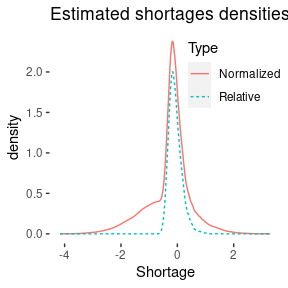

```r
if (requireNamespace("ggplot2", quietly = TRUE)) {
  pdt <- tibble::tibble(
    Shortage = c(mdt$normalized_shortages, mdt$relative_shortages),
    Type = c(rep("Normalized", nrow(mdt)), rep("Relative", nrow(mdt))),
    xpos = c(rep(-1.0, nrow(mdt)), rep(1.0, nrow(mdt))),
    ypos = c(
      rep(0.8 * max(mdt$normalized_shortages), nrow(mdt)),
      rep(0.8 * max(mdt$relative_shortages), nrow(mdt))
    )
  )
  ggplot2::ggplot(pdt) +
    ggplot2::stat_density(ggplot2::aes(Shortage,
      linetype = Type,
      color = Type
    ), geom = "line") +
    ggplot2::ggtitle(paste0("Estimated shortages densities (", model_name(fit), ")")) +
    ggplot2::theme(
      panel.background = ggplot2::element_rect(fill = "transparent"),
      plot.background = ggplot2::element_rect(
        fill = "transparent",
        color = NA
      ),
      legend.background = ggplot2::element_rect(fill = "transparent"),
      legend.box.background = ggplot2::element_rect(
        fill = "transparent",
        color = NA
      ),
      legend.position = c(0.8, 0.8)
    )
} else {
    summary(mdt[, grep("shortage", colnames(mdt))])
}
```

### Fitted values and aggregation

The estimated demanded and supplied quantities can be calculated per observation.

```r
market <- cbind(
  demand = demanded_quantities(fit)[, 1],
  supply = supplied_quantities(fit)[, 1]
)
summary(market)
```

```
#>      demand          supply
#>  Min.   :3.175   Min.   : 2.529
#>  1st Qu.:5.241   1st Qu.: 5.670
#>  Median :5.684   Median : 6.366
#>  Mean   :5.683   Mean   : 6.362
#>  3rd Qu.:6.129   3rd Qu.: 7.054
#>  Max.   :8.148   Max.   :10.747
```

The package also offers basic aggregation functionality.

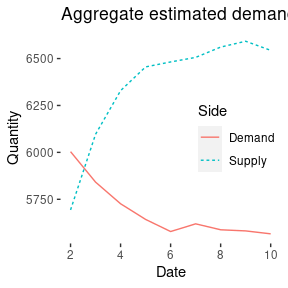

```r
aggregates <- aggregate_demand(fit) %>%
  dplyr::left_join(aggregate_supply(fit), by = "date") %>%
  dplyr::mutate(date = as.numeric(date)) %>%
  dplyr::rename(demand = D_Q, supply = S_Q)
if (requireNamespace("ggplot2", quietly = TRUE)) {
  pdt <- tibble::tibble(
    Date = c(aggregates$date, aggregates$date),
    Quantity = c(aggregates$demand, aggregates$supply),
    Side = c(rep("Demand", nrow(aggregates)), rep("Supply", nrow(aggregates)))
  )
  ggplot2::ggplot(pdt, ggplot2::aes(x = Date)) +
    ggplot2::geom_line(ggplot2::aes(y = Quantity, linetype = Side, color = Side)) +
    ggplot2::ggtitle(paste0(
      "Aggregate estimated demand and supply  (", model_name(fit), ")"
    )) +
    ggplot2::theme(
      panel.background = ggplot2::element_rect(fill = "transparent"),
      plot.background = ggplot2::element_rect(
        fill = "transparent", color = NA
      ),
      legend.background = ggplot2::element_rect(fill = "transparent"),
      legend.box.background = ggplot2::element_rect(
        fill = "transparent", color = NA
      ),
      legend.position = c(0.8, 0.5)
    )
} else {

    aggregates
}
```